# Problem Description

Ulrike Genschel, Kiegan Rice

#### Things to make sure we have loaded when working with this data:

```r
library(devtools)
library(tidyverse)
devtools::install_github("erichare/bulletr")
library(bulletr)
```

#### How can we identify the location of the grooves at the edge of a bullet land?

*What information do we have?*

1. 3D bullet scan data in x3p format: in a matrix, values are ‘z’ (height) values.
2. 3D bullet scan data in data frame format: using `fortify_x3p` from Eric’s `bulletr` package, we can get `x`, `y`, and `value` columns. These `x` and `y` have been converted to the actual micrometer location values instead of indices.
3. Profiles of bullet lands
   - For a specific value of `x`, we can plot the profile by plotting `z` vs the `y` values.

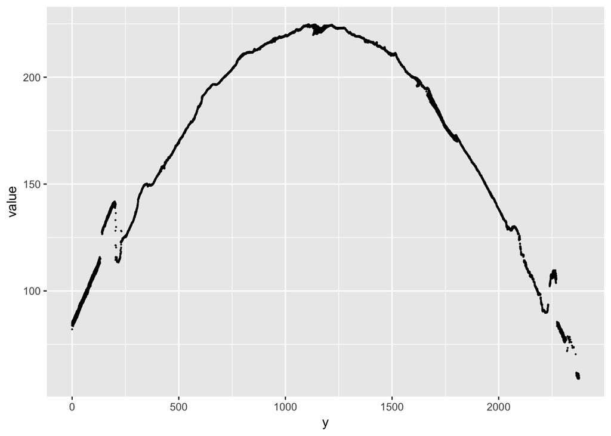

```r
br411_df <- bulletr::fortify_x3p(br411)
br411_df %>% filter(between(x, 100, 110)) %>% ggplot() + geom_point(aes(x = y, y = value), size = .1)
```

4. `get_grooves` function in `bulletr` package. This is the current method of identifying the grooves at the edge of the bullet lands. According to Eric’s dissertation (not the code in `bulletr`):
   - This is an algorithm that first finds the peak of the groove and follows the descent inwards to find the valley of the groove.
   - Uses a rolling average with a smoothing factor and applies this smoothing twice.
   - Once the profile has been twice-smoothed, it identifies the maximum (peak) and then minimum (valley)
   - It finds the peak by finding the first doubly-smoothed value $y_i$ that is a maximum within its smoothing window {$y_i > y_{i-1}$ and $y_i > y_{i+1}$, $i \in (1, \lfloor\frac{s}{2}\rfloor)$}
   - It then finds the valley by finding the first doubly-smoothed value $y_j$ that is a minimum within its smoothing window {$y_j < y_{j-1}$ and $y_j < y_{j+1}$}.

*Questions we have about the algorithm*

1. $S$, the smoothing factor: how is this determined?  
   *Somewhere between cross validation and ad-hoc. Not sure which.*
2. Y values at the end points, before $y_{18}$ and after $y_{n-18}$  
   *NA values for the first 18*
3. Why the second smoothing? Paper explains, but not super clear still.  
   *Results are better*
4. Indexing: why $i \in (1, \lfloor\frac{s}{2}\rfloor)$
5. The identified grooves in the ‘profiles’ table - are those correct, and to be used for reference?  
   *Function with multiple methods for finding the grooves*
6. Is the function taking the rolling median or the rolling mean?  
   *The mean*